# A5: Incarceration

### Introduction

The variables this report will analyze will be:

1. the change in number of prisoners for all races in WA over time in order to see how the race compositions of prisoners over WA state have changed over time
2. the relationship between the white jail population rates compared to the black jail populations rates to determine if there's a correlation between white people being incarcerated vs POC being incarcerated
3. the distribution of race of prisoners in a county on a map to see a clearer concentration of what compositions of prisoners are in each county today and whether there is still inequality

### Summary Information

```
## $county_highest_prison_pop
##     county_name total_jail_pop_rate
## 1 Yakima County              992.82
##
## $county_lowest_prison_pop
##      county_name total_jail_pop_rate
## 1 Whitman County               81.31
##
## $highest_poc_prison_pop
##   highest_poc_prison_pop
## 1                 8215.3
##
## $county_highest_poc_prison
## # A tibble: 1 × 2
##   county_name  county_highest_poc_prison
##   <chr>                            <dbl>
## 1 Adams County                     4255.
##
## $year_highest_prisoners
##   year   county_name total_jail_pop_rate
## 1 2009 Yakima County              992.82
```

### The Dataset

The data was collected by the Vera Institute of Justice.

The data was collected in various ways by the Vera Institute. Some ways are from the government and government agencies, criminal settings such as jails and courtrooms, city/town halls. This Washington dataset may have been retrieved using data from the WA state government and similar areas.

The data was collected in order to bring about ending mass incarceration and searching for solutions to do that. The Vera Institute wants to transform the justice system and they can do so by studying prison populations and demographics of who is in prison to determine if there's bias towards particular groups of people.

```r
print(nrow(wa_data))
```

```
## [1] 1131
```

There are 1131 rows in this dataset.

How many features (columns) are in the data?

```r
print(ncol(wa_data))
```

```
## [1] 23
```

There are 23 columns in this dataset.

The ethical concerns with this data are that since this data was gathered by the Vera Institute from various sources, it is unknown if there is under-reporting or over-reporting of poeple who are actually in prisons during specific times. This can cause issues as it may not accurately represent number of POC in prisons which is what our analysis is trying to cover.

The limitations are that this data only has the races of people who are in prison in WA state, and it's a small amount of data compared to the entire set. The data also does not have the reasonings behind why prisoners are in prison. We won't be able to know the severity of crimes and peoples' sentences in prison, which may or may not play a role in determining why the demographics of prisoners is the way it is. So essentially, the dataset is generalized and we do not know the specifics. It also has a lot of N/A columns for population of specific races in prisons. This further adds to the issues and questions of how accurate the demographics are. It also only sorts the races into male and female, aapi, black, latinx, native, and white, so we have to consider that while the races and sexes are generally accounted for, it is unsure how people who are a mix of these may be represented in this data. Some counties will smaller populations may also not have enough representation compared to counties with larger populations. Also, if we are looking at this for only Washington state, it raises a lot of questions for how the data will be represented in other states' datasets too.

### Trends Over Time Chart

This chart shows the jail population rates of various racial groups in King County jails from the year 1990 to 2018. This chart was included in order to research any over-incarceration of races in King County and whether or not that has changed over time. The results are really interesting, as it shows black people were over-incarcerated in the 1990s, but that has steadily decrease over time to 2018, showing that while they are still over-incarcerated, the amount of black people in prison has decreased overall. Latinx people had a spike in incarcerations in 1997 but that has also decreased. Overall though, POC have higher rates of incarceration than white people.

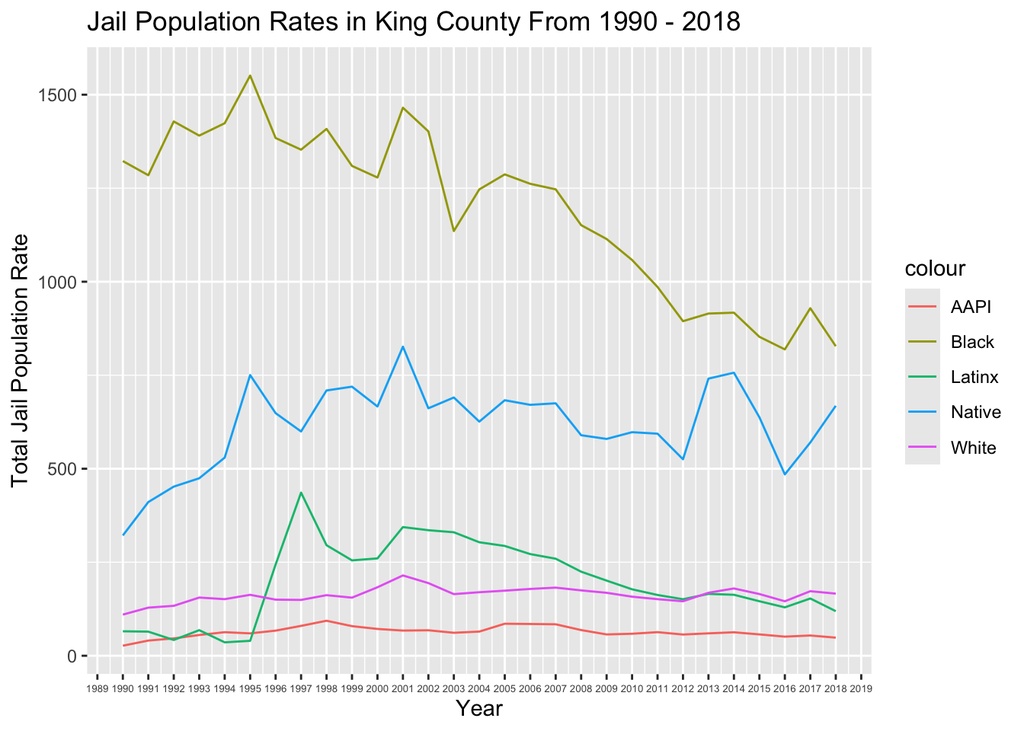

### Variable Comparison Chart

This chart is a variable comparison of the white jail population rates to the black jail population rates from 1990 - 2018 in King County. This chart was included in order to determine if there's any correlation between the incarceration of black people vs white people in King County over the years to uncover any racial disparities between POC and white people being incarcerated, but there appears to not be a clear relationship. The correlation coefficient of 0.01726 is not very strong so it cannot be said whether the incarceration of black people had an effect on white people and vice versa.

```
## [1] 0.01726384
```

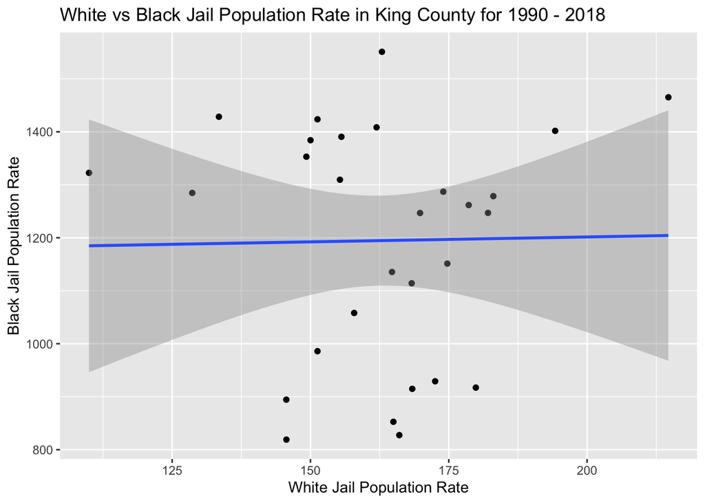

### Map

This chart is a set of maps showing the jail population rates of various races in counties in WA state. They are denoted by a legend where the lighter blue shows a higher amount of people of that race are in jail, and this is a sum of all people in jail from 1990 to 2018. This chart was included to determine which counties are more prone to overincarcerating POC, and how the composition of people in jail varies by county. Based off the numbers and colors, the patterns show that there is a greater amount of POC in jail in WA state counties (over 1000) compared to white people (mostly under 1000 in counties), so there may be some evidence of over-incarceration of POC.

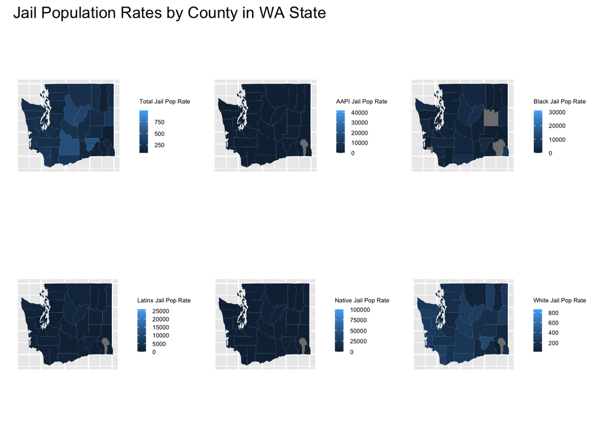